# respostas_ex02_21202510146_dias

Debora Rodrigues Pereira Dias

2026-01-31

## R Markdown

Lista de Exercícios II — Tipos de Variáveis e Estatísticas Descritivas Turma: PPU00920253 Matrícula: 21202510146 Nome: Debora Rodrigues Pereira Dias

## Tarefa 1 — Preparação do ambiente e inspeção da base

```r
# Instalação (só precisa rodar uma vez)


# Carregamento (sempre que abrir o R)
library(tidyverse)
library(readr)
library(ggplot2)
library(dplyr) # para usar count()

options(scipen = 999) # evita notação científica

# Lê o arquivo educ_saude.csv que está dentro da subpasta "data"
dados <- read_csv("data/educ_saude.csv")

# Estrutura geral: nº de linhas/colunas e tipo de cada variável
glimpse(dados)
```

```
## Rows: 10,000
## Columns: 13
## $ id                <chr> "P00001", "P00002", "P00003", "P00004", "P00005", "P…
## $ sexo              <chr> "M", "F", "F", "F", "F", "F", "F", "F", "F", "F", "M…
## $ escolaridade      <chr> "Médio", "Médio", "Médio", "Médio", "Médio", "Médio"…
## $ anos_estudo       <dbl> 10, 9, 9, 10, 11, 11, 10, 8, 15, 11, 6, 7, 5, 4, 10,…
## $ rede_escolar      <chr> "privada", "pública", "pública", "pública", "pública…
## $ municipio         <chr> "Santos", "Dourados", "Várzea Grande", "Curitiba", "…
## $ UF                <chr> "SP", "MS", "MT", "PR", "RJ", "SP", "SC", "SP", "SP"…
## $ idade             <dbl> 39, 30, 31, 44, 26, 51, 47, 48, 25, 53, 23, 27, 35, …
## $ faltas_esc        <dbl> 0, 0, 1, 0, 1, 0, 1, 0, 1, 0, 0, 0, 0, 0, 2, 0, 0, 0…
## $ tempo_estudo_h    <dbl> 2.3, 6.6, 8.8, 4.2, 3.7, 4.9, 0.2, 1.9, 14.4, 3.3, 3…
## $ pressao_sistolica <dbl> 110, 109, 121, 131, 134, 124, 139, 124, 132, 134, 13…
## $ diagnostico       <chr> "sem", "sem", "sem", "sem", "sem", "HAS", "sem", "se…
## $ plano_saude       <chr> "privado", "privado", "nenhum", "nenhum", "SUS", "pr…
```

```r
# Estatísticas descritivas básicas
summary(dados)
```

```
##       id                sexo           escolaridade        anos_estudo
##  Length:10000       Length:10000       Length:10000       Min.   : 4.00
##  Class :character   Class :character   Class :character   1st Qu.: 8.00
##  Mode  :character   Mode  :character   Mode  :character   Median :11.00
##                                                           Mean   :10.74
##                                                           3rd Qu.:13.00
##                                                           Max.   :20.00
##  rede_escolar        municipio              UF                idade
##  Length:10000       Length:10000       Length:10000       Min.   :18.00
##  Class :character   Class :character   Class :character   1st Qu.:31.00
##  Mode  :character   Mode  :character   Mode  :character   Median :40.00
##                                                           Mean   :40.39
##                                                           3rd Qu.:49.00
##                                                           Max.   :80.00
##    faltas_esc     tempo_estudo_h   pressao_sistolica diagnostico
##  Min.   :0.0000   Min.   : 0.000   Min.   : 85.0     Length:10000
##  1st Qu.:0.0000   1st Qu.: 2.800   1st Qu.:112.0     Class :character
##  Median :0.0000   Median : 5.000   Median :122.0     Mode  :character
##  Mean   :0.2346   Mean   : 6.122   Mean   :122.2
##  3rd Qu.:0.0000   3rd Qu.: 8.200   3rd Qu.:131.0
##  Max.   :3.0000   Max.   :34.300   Max.   :175.0
##  plano_saude
##  Length:10000
##  Class :character
##  Mode  :character
##
##
##
```

```r
# Número de linhas e colunas
nrow(dados)  # total de linhas (observações)
```

```
## [1] 10000
```

```r
ncol(dados)  # total de colunas (variáveis)
```

```
## [1] 13
```

```r
# Classes das variáveis
str(dados)
```

```
## spc_tbl_ [10,000 × 13] (S3: spec_tbl_df/tbl_df/tbl/data.frame)
##  $ id               : chr [1:10000] "P00001" "P00002" "P00003" "P00004" ...
##  $ sexo             : chr [1:10000] "M" "F" "F" "F" ...
##  $ escolaridade     : chr [1:10000] "Médio" "Médio" "Médio" "Médio" ...
##  $ anos_estudo      : num [1:10000] 10 9 9 10 11 11 10 8 15 11 ...
##  $ rede_escolar     : chr [1:10000] "privada" "pública" "pública" "pública" ...
##  $ municipio        : chr [1:10000] "Santos" "Dourados" "Várzea Grande" "Curitiba" ...
##  $ UF               : chr [1:10000] "SP" "MS" "MT" "PR" ...
##  $ idade            : num [1:10000] 39 30 31 44 26 51 47 48 25 53 ...
##  $ faltas_esc       : num [1:10000] 0 0 1 0 1 0 1 0 1 0 ...
##  $ tempo_estudo_h   : num [1:10000] 2.3 6.6 8.8 4.2 3.7 4.9 0.2 1.9 14.4 3.3 ...
##  $ pressao_sistolica: num [1:10000] 110 109 121 131 134 124 139 124 132 134 ...
##  $ diagnostico      : chr [1:10000] "sem" "sem" "sem" "sem" ...
##  $ plano_saude      : chr [1:10000] "privado" "privado" "nenhum" "nenhum" ...
##  - attr(*, "spec")=
##   .. cols(
##   ..   id = col_character(),
##   ..   sexo = col_character(),
##   ..   escolaridade = col_character(),
##   ..   anos_estudo = col_double(),
##   ..   rede_escolar = col_character(),
##   ..   municipio = col_character(),
##   ..   UF = col_character(),
##   ..   idade = col_double(),
##   ..   faltas_esc = col_double(),
##   ..   tempo_estudo_h = col_double(),
##   ..   pressao_sistolica = col_double(),
##   ..   diagnostico = col_character(),
##   ..   plano_saude = col_character()
##   .. )
##  - attr(*, "problems")=<externalptr>
```

```r
# Verificação de valores ausentes (NA)
sum(is.na(dados))       # total de NA na base
```

```
## [1] 0
```

```r
colSums(is.na(dados))   # total de NA por coluna
```

```
##                id              sexo      escolaridade       anos_estudo
##                 0                 0                 0                 0
##      rede_escolar         municipio                UF             idade
##                 0                 0                 0                 0
##        faltas_esc    tempo_estudo_h pressao_sistolica       diagnostico
##                 0                 0                 0                 0
##       plano_saude
##                 0
```

Interpretação:  
A base possui 10.000 linhas e 13 variáveis. Oito variáveis são qualitativas (texto/chr) e cinco são quantitativas (números/dbl). Não foram identificados valores ausentes (NA) nesta inspeção inicial.

Tarefa 2 — Classificação de variáveis e ajuste de tipos

```r
dados <- dados |>
  mutate(
    sexo         = factor(sexo),                # qualitativa nominal (categorias F/M sem ordem)
    rede_escolar = factor(rede_escolar),        # qualitativa nominal (pública/privada sem hierarquia)
    plano_saude  = factor(plano_saude),         # qualitativa nominal (SUS/privado/ambos/nenhum)
    diagnostico  = factor(diagnostico),         # qualitativa nominal ("sem", "HAS", "DM", "outros")
    escolaridade = factor(escolaridade,
                          levels = c("Fundamental","Médio","Superior"),
                          ordered = TRUE)       # qualitativa ordinal (há hierarquia entre níveis)
  )

# Tabela de classificação teórica
dfl <- data.frame(
  variavel=c("id","sexo","escolaridade","anos_estudo","rede_escolar","municipio","UF",
             "idade","faltas_esc","tempo_estudo_h","pressao_sistolica","diagnostico","plano_saude"),
  tipoteorico=c("nominal","nominal","ordinal","discreta","nominal","nominal","nominal",
                "contínua","discreta","contínua","contínua","nominal","nominal"),
  stringsAsFactors=FALSE
)

dfl
```

```
##             variavel tipoteorico
## 1                 id     nominal
## 2               sexo     nominal
## 3       escolaridade     ordinal
## 4        anos_estudo    discreta
## 5       rede_escolar     nominal
## 6          municipio     nominal
## 7                 UF     nominal
## 8              idade    contínua
## 9         faltas_esc    discreta
## 10    tempo_estudo_h    contínua
## 11 pressao_sistolica    contínua
## 12       diagnostico     nominal
## 13       plano_saude     nominal
```

```r
# Conferência da estrutura
str(dados)
```

```
## tibble [10,000 × 13] (S3: tbl_df/tbl/data.frame)
##  $ id               : chr [1:10000] "P00001" "P00002" "P00003" "P00004" ...
##  $ sexo             : Factor w/ 2 levels "F","M": 2 1 1 1 1 1 1 1 1 1 ...
##  $ escolaridade     : Ord.factor w/ 3 levels "Fundamental"<..: 2 2 2 2 2 2 1 1 3 2 ...
##  $ anos_estudo      : num [1:10000] 10 9 9 10 11 11 10 8 15 11 ...
##  $ rede_escolar     : Factor w/ 2 levels "privada","pública": 1 2 2 2 2 2 2 2 2 2 ...
##  $ municipio        : chr [1:10000] "Santos" "Dourados" "Várzea Grande" "Curitiba" ...
##  $ UF               : chr [1:10000] "SP" "MS" "MT" "PR" ...
##  $ idade            : num [1:10000] 39 30 31 44 26 51 47 48 25 53 ...
##  $ faltas_esc       : num [1:10000] 0 0 1 0 1 0 1 0 1 0 ...
##  $ tempo_estudo_h   : num [1:10000] 2.3 6.6 8.8 4.2 3.7 4.9 0.2 1.9 14.4 3.3 ...
##  $ pressao_sistolica: num [1:10000] 110 109 121 131 134 124 139 124 132 134 ...
##  $ diagnostico      : Factor w/ 4 levels "DM","HAS","outros",..: 4 4 4 4 4 2 4 4 4 4 ...
##  $ plano_saude      : Factor w/ 4 levels "ambos","nenhum",..: 3 3 2 2 4 3 4 4 3 2 ...
```

```r
glimpse(dados)
```

```
## Rows: 10,000
## Columns: 13
## $ id                <chr> "P00001", "P00002", "P00003", "P00004", "P00005", "P…
## $ sexo              <fct> M, F, F, F, F, F, F, F, F, F, M, F, F, M, F, F, M, F…
## $ escolaridade      <ord> Médio, Médio, Médio, Médio, Médio, Médio, Fundamenta…
## $ anos_estudo       <dbl> 10, 9, 9, 10, 11, 11, 10, 8, 15, 11, 6, 7, 5, 4, 10,…
## $ rede_escolar      <fct> privada, pública, pública, pública, pública, pública…
## $ municipio         <chr> "Santos", "Dourados", "Várzea Grande", "Curitiba", "…
## $ UF                <chr> "SP", "MS", "MT", "PR", "RJ", "SP", "SC", "SP", "SP"…
## $ idade             <dbl> 39, 30, 31, 44, 26, 51, 47, 48, 25, 53, 23, 27, 35, …
## $ faltas_esc        <dbl> 0, 0, 1, 0, 1, 0, 1, 0, 1, 0, 0, 0, 0, 0, 2, 0, 0, 0…
## $ tempo_estudo_h    <dbl> 2.3, 6.6, 8.8, 4.2, 3.7, 4.9, 0.2, 1.9, 14.4, 3.3, 3…
## $ pressao_sistolica <dbl> 110, 109, 121, 131, 134, 124, 139, 124, 132, 134, 13…
## $ diagnostico       <fct> sem, sem, sem, sem, sem, HAS, sem, sem, sem, sem, HA…
## $ plano_saude       <fct> privado, privado, nenhum, nenhum, SUS, privado, SUS,…
```

Interpretação:

Nominais: id, sexo, rede_escolar, municipio, UF, diagnostico, plano_saude.

Ordinal: escolaridade (há hierarquia entre Fundamental < Médio < Superior).

Discretas: anos_estudo, faltas_esc.

Contínuas: idade, tempo_estudo_h, pressao_sistolica.

Após o ajuste com mutate(), as variáveis qualitativas foram convertidas em fatores e escolaridade foi definida como ordinal. Essa coerência entre tipo teórico e classe no R é essencial para aplicar estatísticas e gráficos corretamente, evitando interpretações equivocadas.

Tarefa 3A — Frequências absolutas e relativas

```r
# Frequências absolutas e relativas do plano de saúde
tab_plano <- table(dados$plano_saude)
prop_plano <- prop.table(tab_plano)
cbind(FA = tab_plano, FR = round(100 * prop_plano, 1))
```

```
##           FA   FR
## ambos    634  6.3
## nenhum  1868 18.7
## privado 2474 24.7
## SUS     5024 50.2
```

Interpretação:  
A moda é a categoria “SUS”, com 5024 pessoas. A proporção dominante é 50,2%, indicando que metade dos entrevistados depende do SUS. As demais categorias aparecem em menor proporção: privado (24,7%), nenhum (18,7%) e ambos (6,3%). Esses resultados mostram a predominância do SUS como principal forma de acesso à saúde.

Tarefa 3B — Gráfico de barras (qualitativa nominal)

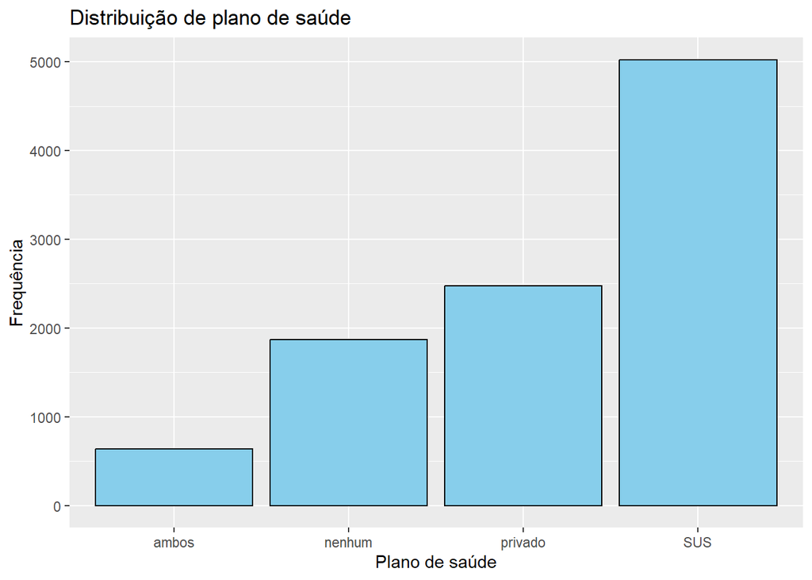

```r
dados |>
  count(plano_saude) |>
  ggplot(aes(x = plano_saude, y = n)) +
  geom_col(fill = "skyblue", color = "black") +
  labs(x = "Plano de saúde", y = "Frequência",
       title = "Distribuição de plano de saúde")
```

Interpretação:  
O gráfico mostra a distribuição dos planos de saúde. A categoria “SUS” aparece como a mais frequente, confirmando a moda e a proporção dominante já observadas na Tarefa 3A. As categorias “privado”, “nenhum” e “ambos” aparecem em proporções menores, reforçando a predominância do SUS na amostra. O gráfico facilita a comparação visual entre categorias.

Tarefa 3C — Barras ordenadas (qualitativa ordinal)

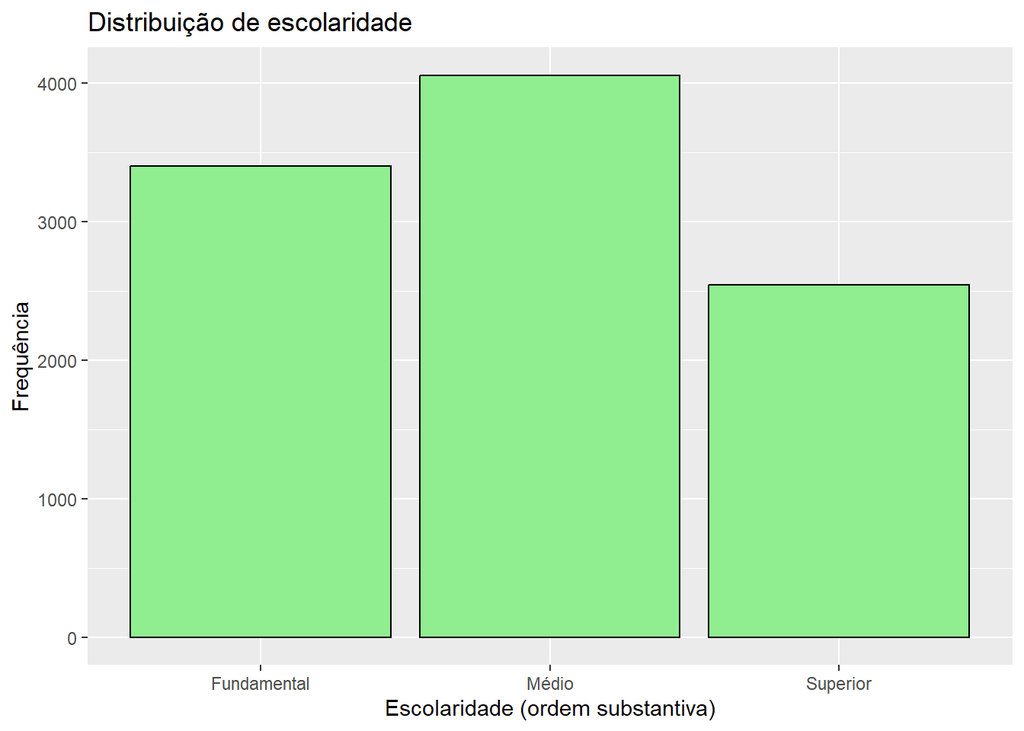

```r
dados |>
  count(escolaridade) |>
  ggplot(aes(x = escolaridade, y = n)) +
  geom_col(fill = "lightgreen", color = "black") +
  labs(x = "Escolaridade (ordem substantiva)", y = "Frequência",
       title = "Distribuição de escolaridade")
```

Interpretação:  
O gráfico mostra a distribuição dos níveis de escolaridade. A ordem das categorias é fundamental porque “escolaridade” é uma variável ordinal. Com a ordem correta (Fundamental < Médio < Superior), conseguimos interpretar a progressão dos níveis educacionais e comparar a distribuição de forma substantiva. Se as barras fossem mostradas em ordem aleatória, perderíamos essa hierarquia e a análise ficaria prejudicada.

Tarefa 4A — Tendência central e dispersão

```r
# Resumo para idade
sumario_idade <- dados |>
  summarise(
    n = sum(!is.na(idade)),
    media = mean(idade, na.rm = TRUE),
    mediana= median(idade, na.rm = TRUE),
    min = min(idade, na.rm = TRUE),
    max = max(idade, na.rm = TRUE),
    dp  = sd(idade, na.rm = TRUE)
  )
sumario_idade
```

```
## # A tibble: 1 × 6
##       n media mediana   min   max    dp
##   <int> <dbl>   <dbl> <dbl> <dbl> <dbl>
## 1 10000  40.4      40    18    80  12.5
```

```r
# Resumo para pressão sistólica
sumario_pressao <- dados |>
  summarise(
    n = sum(!is.na(pressao_sistolica)),
    media = mean(pressao_sistolica, na.rm = TRUE),
    mediana= median(pressao_sistolica, na.rm = TRUE),
    min = min(pressao_sistolica, na.rm = TRUE),
    max = max(pressao_sistolica, na.rm = TRUE),
    dp  = sd(pressao_sistolica, na.rm = TRUE)
  )
sumario_pressao
```

```
## # A tibble: 1 × 6
##       n media mediana   min   max    dp
##   <int> <dbl>   <dbl> <dbl> <dbl> <dbl>
## 1 10000  122.     122    85   175  14.1
```

Interpretação:

Idade: média (40,4) ≈ mediana (40), indicando simetria. Intervalo de 18 a 80 anos, com dispersão moderada (dp = 12,5).

Pressão sistólica: média (122) = mediana (122), também simétrica. Valores entre 85 e 175 mmHg, com dispersão moderada (dp = 14,1). Esses resultados indicam distribuições aproximadamente simétricas, sem grandes desvios entre média e mediana, sugerindo ausência de forte assimetria nos dados.

Tarefa 4B — Histograma e boxplot

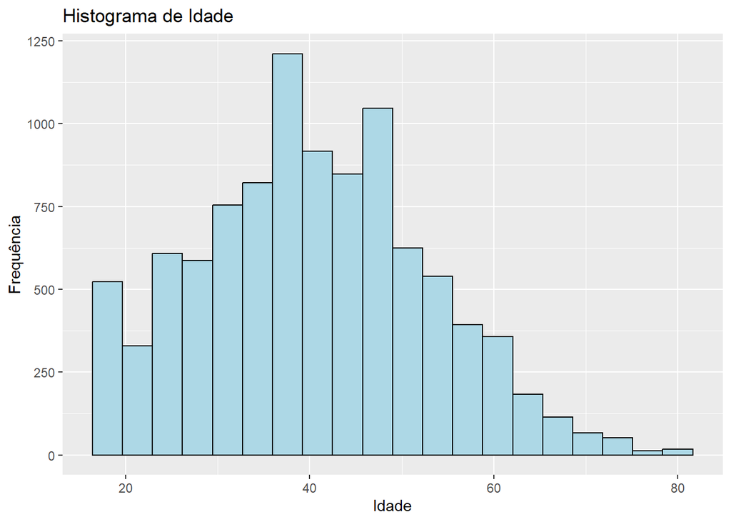

```r
# Idade
ggplot(dados, aes(x = idade)) +
  geom_histogram(bins = 20, fill = "lightblue", color = "black") +
  labs(title = "Histograma de Idade", x = "Idade", y = "Frequência")
```

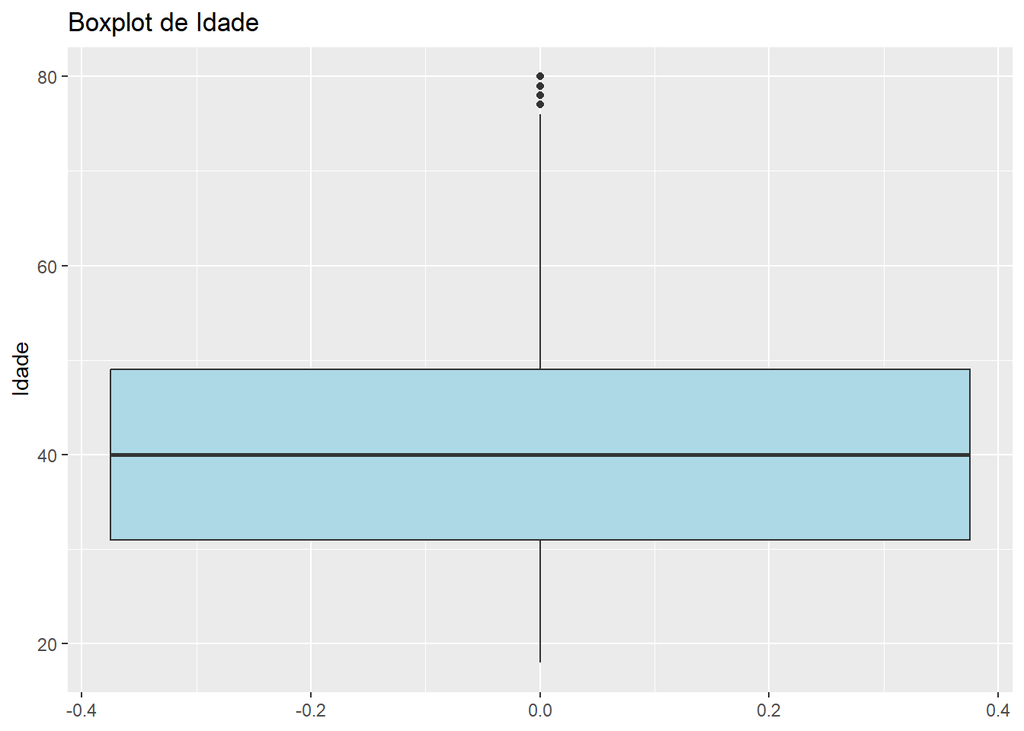

```r
ggplot(dados, aes(y = idade)) +
  geom_boxplot(fill = "lightblue") +
  labs(title = "Boxplot de Idade", y = "Idade")
```

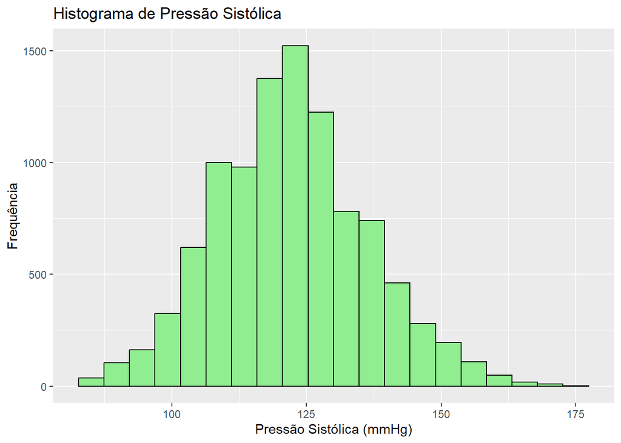

```r
# Pressão Sistólica
ggplot(dados, aes(x = pressao_sistolica)) +
  geom_histogram(bins = 20, fill = "lightgreen", color = "black") +
  labs(title = "Histograma de Pressão Sistólica", x = "Pressão Sistólica (mmHg)", y = "Frequência")
```

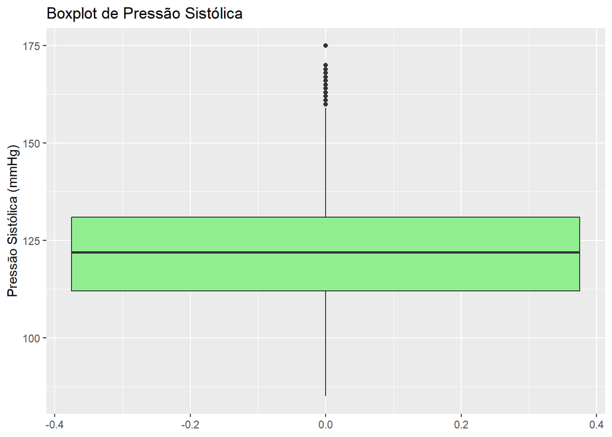

```r
ggplot(dados, aes(y = pressao_sistolica)) +
  geom_boxplot(fill = "lightgreen") +
  labs(title = "Boxplot de Pressão Sistólica", y = "Pressão Sistólica (mmHg)")
```

Interpretação:

Idade: distribuição simétrica, caudas curtas, poucos outliers.

Pressão sistólica: distribuição simétrica, caudas moderadas, alguns valores extremos. Esses gráficos complementam as medidas descritivas, permitindo visualizar a forma da distribuição e identificar valores extremos de maneira intuitiva.

Tarefa 5A — Qual diagnóstico é mais prevalente dentro de cada tipo de plano?

```r
# Tabela cruzada diagnóstico × plano de saúde
tab_cross <- table(dados$diagnostico, dados$plano_saude)
tab_cross
```

```
##
##          ambos nenhum privado  SUS
##   DM         6     21      18   44
##   HAS       77    227     300  626
##   outros    35    112     163  302
##   sem      516   1508    1993 4052
```

```r
# Percentuais por coluna (plano de saúde)
round(100 * prop.table(tab_cross, margin = 2), 1)
```

```
##
##          ambos nenhum privado  SUS
##   DM       0.9    1.1     0.7  0.9
##   HAS     12.1   12.2    12.1 12.5
##   outros   5.5    6.0     6.6  6.0
##   sem     81.4   80.7    80.6 80.7
```

Interpretação:  
Em todos os planos de saúde, a maioria dos indivíduos está na categoria “sem diagnóstico” (≈ 80%). Entre os diagnósticos presentes, HAS é o mais prevalente em todos os planos (≈ 12%), seguido por “outros” e DM, com proporções menores. Observa-se pequena variação: HAS é ligeiramente mais frequente no SUS (12,5%). Esse cruzamento mostra que a ausência de diagnóstico é predominante em todos os planos, mas a hipertensão (HAS) aparece como o principal problema de saúde identificado, especialmente entre usuários do SUS.

Tarefa 5B.1 — Resumo de idade por sexo

```r
dados |>
  group_by(sexo) |>
  summarise(
    n = n(),
    media_idade = mean(idade, na.rm = TRUE),
    dp_idade = sd(idade, na.rm = TRUE),
    mediana_idade = median(idade, na.rm = TRUE)
  )
```

```
## # A tibble: 2 × 5
##   sexo      n media_idade dp_idade mediana_idade
##   <fct> <int>       <dbl>    <dbl>         <dbl>
## 1 F      5192        40.3     12.5            40
## 2 M      4808        40.5     12.4            40
```

Interpretação:  
As médias e medianas de idade são praticamente iguais entre homens (40,5) e mulheres (40,3), indicando distribuições muito semelhantes. O desvio padrão também é próximo (12,4 vs 12,5), mostrando que a variabilidade da idade é equivalente nos dois grupos.

Tarefa 5B.2 — Resumo de idade por escolaridade

```r
dados |>
  group_by(escolaridade) |>
  summarise(
    n = n(),
    media_idade = mean(idade, na.rm = TRUE),
    dp_idade = sd(idade, na.rm = TRUE),
    mediana_idade = median(idade, na.rm = TRUE)
  )
```

```
## # A tibble: 3 × 5
##   escolaridade     n media_idade dp_idade mediana_idade
##   <ord>        <int>       <dbl>    <dbl>         <dbl>
## 1 Fundamental   3399        40.2     12.4            40
## 2 Médio         4056        40.5     12.6            40
## 3 Superior      2545        40.4     12.5            40
```

Interpretação:  
As médias e medianas de idade são praticamente iguais entre os três níveis de escolaridade (≈ 40 anos), indicando distribuições muito semelhantes. Os desvios padrão também são próximos (≈ 12,5), mostrando que a variabilidade da idade não difere de forma relevante entre os grupos.

Conclusão da Tarefa 5

Interpretação final:  
Tanto por sexo quanto por escolaridade, as idades médias e medianas são praticamente iguais, e os desvios padrão também são muito próximos. Isso indica que, neste conjunto de dados, não há diferenças relevantes na distribuição da idade entre os grupos analisados. Os resultados sugerem homogeneidade etária na população estudada.

Tarefa 6A — Valores ausentes

```r
# Verificação de valores ausentes
colSums(is.na(dados))
```

```
##                id              sexo      escolaridade       anos_estudo
##                 0                 0                 0                 0
##      rede_escolar         municipio                UF             idade
##                 0                 0                 0                 0
##        faltas_esc    tempo_estudo_h pressao_sistolica       diagnostico
##                 0                 0                 0                 0
##       plano_saude
##                 0
```

```r
# Exemplo: calcular média de idade com e sem NA
mean(dados$idade)               # dá NA se houver valores ausentes
```

```
## [1] 40.3948
```

```r
mean(dados$idade, na.rm = TRUE) # ignora os NAs
```

```
## [1] 40.3948
```

Interpretação:  
A função colSums(is.na(dados)) mostrou que não há valores ausentes em nenhuma variável. Quando existem NAs, funções como mean() retornam NA se não especificarmos na.rm = TRUE. O argumento na.rm = TRUE serve para ignorar os valores ausentes e calcular a estatística apenas com os dados válidos. No nosso caso, como não há NAs, os resultados são iguais. Esse procedimento é essencial em bases reais, pois garante que estatísticas não sejam invalidadas pela presença de valores ausentes.

Tarefa 6B — Outliers em tempo de estudo

```r
# Identificação de outliers pela regra do IQR
Q <- quantile(dados$tempo_estudo_h, probs = c(.25, .75), na.rm = TRUE)
IQRv <- IQR(dados$tempo_estudo_h, na.rm = TRUE)

lim_inf <- Q[1] - 1.5 * IQRv
lim_sup <- Q[2] + 1.5 * IQRv

subset_out <- dados |>
  filter(tempo_estudo_h < lim_inf | tempo_estudo_h > lim_sup)

nrow(subset_out)   # quantidade de outliers
```

```
## [1] 348
```

```r
head(subset_out)   # primeiros casos de outliers
```

```
## # A tibble: 6 × 13
##   id     sexo  escolaridade anos_estudo rede_escolar municipio       UF    idade
##   <chr>  <fct> <ord>              <dbl> <fct>        <chr>           <chr> <dbl>
## 1 P00033 F     Médio                 11 privada      Blumenau        SC       63
## 2 P00037 M     Superior              15 privada      Pelotas         RS       44
## 3 P00067 M     Superior              14 pública      São Luís        MA       44
## 4 P00086 F     Superior              18 privada      Imperatriz      MA       31
## 5 P00095 F     Superior              15 pública      Rio de Janeiro  RJ       55
## 6 P00183 M     Superior              16 privada      Duque de Caxias RJ       37
## # ℹ 5 more variables: faltas_esc <dbl>, tempo_estudo_h <dbl>,
## #   pressao_sistolica <dbl>, diagnostico <fct>, plano_saude <fct>
```

Interpretação:  
Foram identificados 348 outliers em tempo_estudo_h pela regra do IQR. Esses valores estão acima do limite superior calculado e representam tempos de estudo bem maiores que a maioria dos casos.

Outliers podem ter diferentes significados:

Erros de digitação ou coleta (valores exagerados ou improváveis).

Casos raros (indivíduos que realmente estudaram muito mais que os demais).

Informações válidas que refletem diversidade real da amostra.

A decisão sobre como tratá-los depende do contexto da análise: em alguns estudos podem ser removidos, em outros podem trazer insights importantes sobre comportamentos extremos. Portanto, a análise de outliers deve sempre considerar o contexto substantivo, evitando exclusões automáticas que possam eliminar informações relevantes.

Tarefa 7 - Exercícios aplicados (Educação e Saúde)

7A Educação (a) — Distribuição de rede_escolar (FA/FR)

```r
# Frequência absoluta (FA) e relativa (FR) da rede escolar
tab_rede <- table(dados$rede_escolar)
tab_rede
```

```
##
## privada pública
##    2796    7204
```

```r
prop_rede <- prop.table(tab_rede) * 100
round(prop_rede, 1)
```

```
##
## privada pública
##      28      72
```

Interpretação:  
A frequência absoluta mostra que 2796 alunos estão na rede privada e 7204 alunos na rede pública. A frequência relativa indica que 28% pertencem à rede privada e 72% à rede pública. Portanto, a maioria dos alunos da amostra está na rede pública.

7B Educação (b/c) — Tempo de estudo por escolaridade

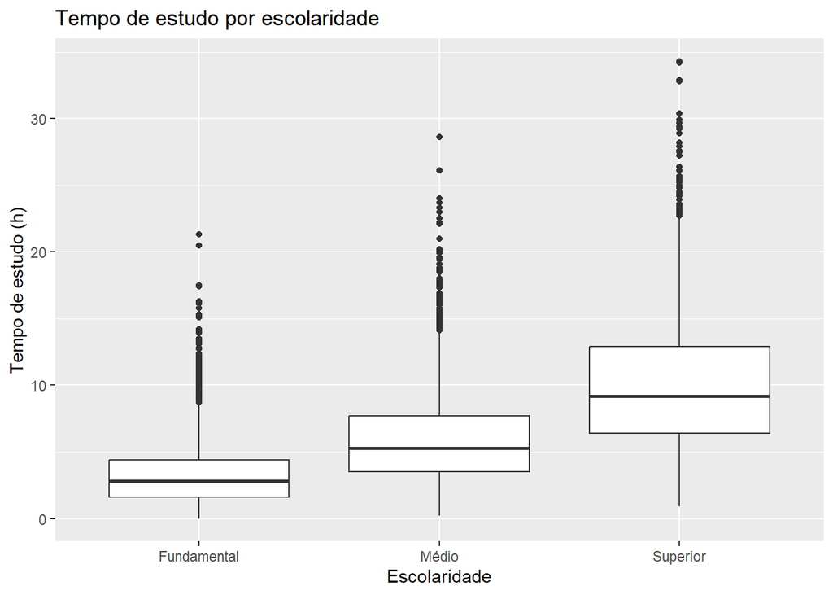

```r
# Boxplots de tempo de estudo por escolaridade
ggplot(dados, aes(x = escolaridade, y = tempo_estudo_h)) +
  geom_boxplot() +
  labs(title = "Tempo de estudo por escolaridade",
       x = "Escolaridade",
       y = "Tempo de estudo (h)")
```

7C Saúde (a) — Histograma de pressão sistólica e estatísticas resumo

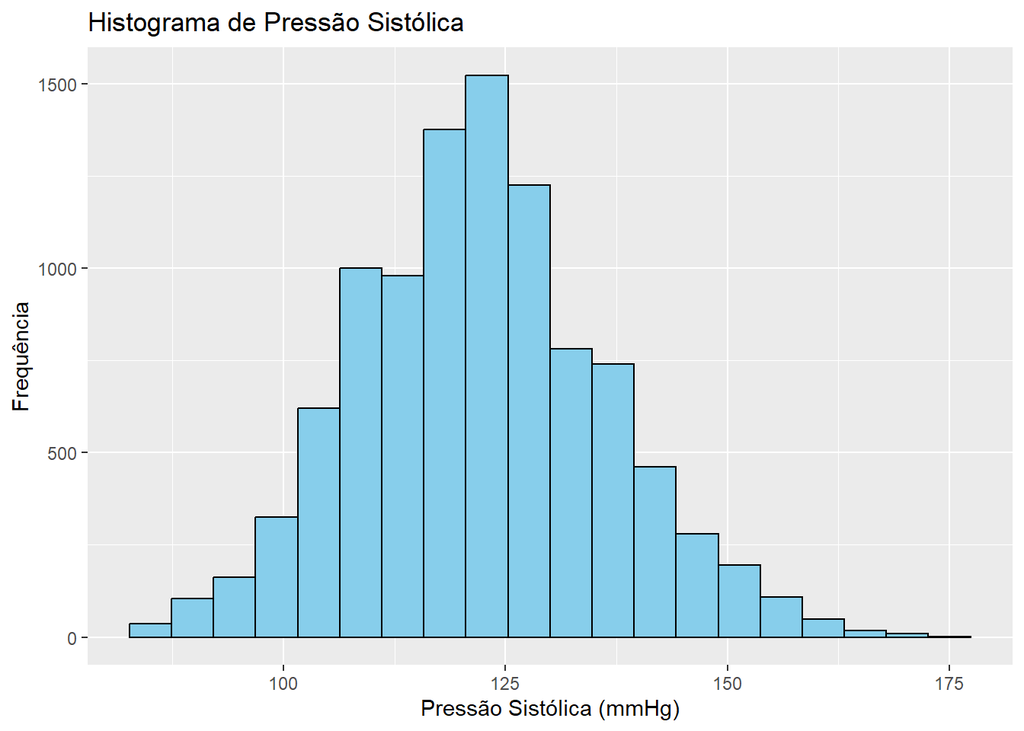

```r
# Histograma de pressão sistólica
ggplot(dados, aes(x = pressao_sistolica)) +
  geom_histogram(bins = 20, fill = "skyblue", color = "black") +
  labs(title = "Histograma de Pressão Sistólica",
       x = "Pressão Sistólica (mmHg)",
       y = "Frequência")
```

```r
# Estatísticas resumo
mean(dados$pressao_sistolica, na.rm = TRUE)
```

```
## [1] 122.1863
```

```r
median(dados$pressao_sistolica, na.rm = TRUE)
```

```
## [1] 122
```

```r
sd(dados$pressao_sistolica, na.rm = TRUE)
```

```
## [1] 14.05137
```

Interpretação:  
O histograma da pressão sistólica mostra uma distribuição aproximadamente simétrica. A média foi de 122,2 mmHg, a mediana 122 mmHg e o desvio padrão 14,0 mmHg. Isso indica que os valores estão concentrados em torno de 120 mmHg, sem grandes desvios, e que a média e a mediana praticamente coincidem, reforçando a simetria da distribuição. A pressão sistólica apresenta distribuição simétrica em torno de 120 mmHg, e a hipertensão (HAS) é o diagnóstico mais prevalente em todos os planos de saúde.

7D Saúde (b/c) — Cruzamento diagnóstico × plano_saude

```r
# Cruzamento diagnostico × plano_saude (% por coluna)
tab_cross <- table(dados$diagnostico, dados$plano_saude)
round(100 * prop.table(tab_cross, margin = 2), 1)
```

```
##
##          ambos nenhum privado  SUS
##   DM       0.9    1.1     0.7  0.9
##   HAS     12.1   12.2    12.1 12.5
##   outros   5.5    6.0     6.6  6.0
##   sem     81.4   80.7    80.6 80.7
```

Interpretação:  
(b) Em todos os planos de saúde, a maioria dos indivíduos está na categoria “sem diagnóstico” (≈ 80%). O diagnóstico de HAS aparece em segundo lugar, com cerca de 12% em todos os planos. Os demais diagnósticos (DM e outros) têm proporções menores, variando entre 0,7% e 6,6%.

3. O diagnóstico mais prevalente em cada plano é HAS, seguido por “outros” e DM. Apesar de pequenas variações entre os planos (HAS ligeiramente mais frequente no SUS), o padrão geral se mantém: HAS é o diagnóstico predominante entre os casos registrados.

9 - Tarefa 8 - Desafio (Tabela-síntese por escolaridade)

```r
# Tabela-síntese por escolaridade
dados %>%
  group_by(escolaridade) %>%
  summarise(
    n = n(),
    media_idade = mean(idade, na.rm = TRUE),
    mediana_idade = median(idade, na.rm = TRUE),
    dp_idade = sd(idade, na.rm = TRUE),
    min_idade = min(idade, na.rm = TRUE),
    max_idade = max(idade, na.rm = TRUE)
  )
```

```
## # A tibble: 3 × 7
##   escolaridade     n media_idade mediana_idade dp_idade min_idade max_idade
##   <ord>        <int>       <dbl>         <dbl>    <dbl>     <dbl>     <dbl>
## 1 Fundamental   3399        40.2            40     12.4        18        80
## 2 Médio         4056        40.5            40     12.6        18        80
## 3 Superior      2545        40.4            40     12.5        18        80
```

```r
# Frequência absoluta e relativa de plano_saude por escolaridade
dados %>%
  group_by(escolaridade, plano_saude) %>%
  summarise(n = n(), .groups = "drop") %>%
  mutate(prop = round(100 * n / sum(n), 1))
```

```
## # A tibble: 12 × 4
##    escolaridade plano_saude     n  prop
##    <ord>        <fct>       <int> <dbl>
##  1 Fundamental  ambos         105   1
##  2 Fundamental  nenhum        857   8.6
##  3 Fundamental  privado       415   4.2
##  4 Fundamental  SUS          2022  20.2
##  5 Médio        ambos         260   2.6
##  6 Médio        nenhum        719   7.2
##  7 Médio        privado       975   9.8
##  8 Médio        SUS          2102  21
##  9 Superior     ambos         269   2.7
## 10 Superior     nenhum        292   2.9
## 11 Superior     privado      1084  10.8
## 12 Superior     SUS           900   9
```

8A Gráfico 1 — Barras empilhadas (proporções de plano_saude por escolaridade)

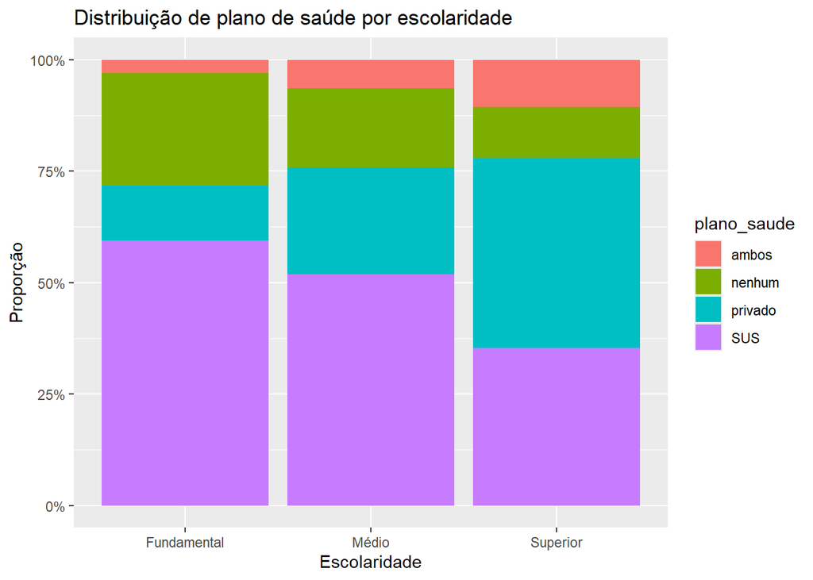

```r
dados %>%
  count(escolaridade, plano_saude) %>%
  group_by(escolaridade) %>%
  mutate(prop = n / sum(n)) %>%
  ggplot(aes(x = escolaridade, y = prop, fill = plano_saude)) +
  geom_col(position = "fill") +
  scale_y_continuous(labels = scales::percent_format()) +
  labs(title = "Distribuição de plano de saúde por escolaridade",
       x = "Escolaridade", y = "Proporção")
```

8B Gráfico 2 — Boxplot de tempo de estudo por escolaridade

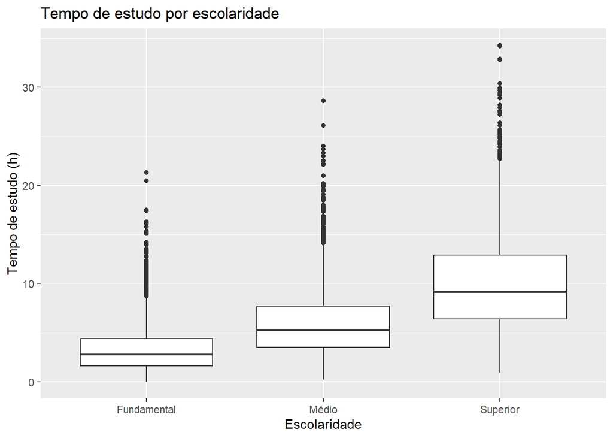

```r
ggplot(dados, aes(x = escolaridade, y = tempo_estudo_h)) +
  geom_boxplot() +
  labs(title = "Tempo de estudo por escolaridade",
       x = "Escolaridade", y = "Tempo de estudo (h)")
```

Conclusão do Desafio Interpretação final:  
O desafio integra estatísticas descritivas, frequências e gráficos, oferecendo uma visão abrangente da relação entre escolaridade, idade, tempo de estudo e acesso à saúde na amostra.

Idade: homogênea entre os níveis de escolaridade.

Conclusão Geral da Lista 2 Interpretação final:  
A Lista 2 permitiu aplicar conceitos de tipos de variáveis e estatísticas descritivas em um conjunto de dados de educação e saúde.

Foram realizadas inspeções iniciais, classificações teóricas, cálculos de frequências, medidas de tendência central e dispersão.

Representações gráficas e tabelas cruzadas mostraram padrões importantes:

Saúde: predominância do SUS como forma de acesso, distribuição simétrica da pressão sistólica em torno de 120 mmHg e hipertensão (HAS) como diagnóstico mais prevalente.

Também foi possível discutir a importância do tratamento de valores ausentes (não identificados na base) e outliers (348 casos em tempo de estudo).

Síntese:  
A análise consolidou a prática de análise exploratória de dados, conectando teoria estatística com aplicações em políticas públicas. Os resultados reforçam a relevância de compreender a natureza das variáveis, aplicar estatísticas descritivas e interpretar gráficos para identificar padrões e variações iniciais nos dados.